# Nonparametric Regression - *notas de aula*

[Henrique Aparecido Laureano](http://lattes.cnpq.br/2224901552085090)

Outubro de 2015

> Todas as informações contidas neste arquivo foram retiradas do capítulo 11 do livro:  
> **Extending the Linear Model with R:**  
> **Generalized Linear, Mixed Effects and Nonparametric Regression Models**  
> de *Julian J. Faraway*  
> Editora Chapman & Hall/CRC, Taylor & Francis Group (**2006**)

# Kernel Estimators

Na sua forma mais simples, ela é apenas um estimador média móvel.

Mais geralmente, nossa estimativa de $f$, chamada $\hat{f}_{\lambda} (x)$, é:

> $\hat{f}_{\lambda} (x) = \frac{1}{n \lambda} \sum_{j = 1}^{n} k \left( \frac{x - x_{j}}{\lambda} \right) Y_{j} = \frac{1}{n} \sum_{j = 1}^{n} w_{j} Y_{j}, \quad \text{onde} \quad w_{j} = k \left( \frac{x - x_{j}}{\lambda} \right) / \lambda$

$k$ é um kernel onde $\int k = 1$.

O kernel de média móvel é retangular, mas kernels suavizadores podem fornecer melhores resultados.

$\lambda$ é chamado de largura da banda, largura da janela ou parâmetro suavizador. Ele controla a suavidade da curva ajustada.

Se os $x$s são espaçados de forma muito desigual, então este estimador pode fornecer pobres resultados. Este problema é um pouco amenizado pelo estimador *Nadaraya-Watson*:

> $f_{\lambda} (x) = \frac{\sum_{j = 1}^{n} w_{j} Y_{j}}{\sum_{j = 1}^{n} w_{j}}$

Nós vemos que este estimador simplesmente modifica o estimador de média móvel então isso é uma verdadeira média ponderada onde os pesos para cada $y$ devem somar um.

> A vantagem da abordagem não-paramétrica é a proteção contra erros de especificação do modelo.

A implementação de um estimador kernel necessita de duas coisas: o kernel ($k$) e o parâmetro suavizador ($\lambda$).

A escolha ótima sob algumas suposições padrão é o kernel Epanechnikov:

> $k(x) = \begin{cases} \frac{3}{4} (1 - x^{2}) & |x| < 1 \\ 0 & \text{caso contrário} \end{cases}$

> A escolha do parâmetro suavizador $\lambda$ é crítica para a performance do estimador e é muito mais importante que a escolha do kernel.

Nós demonstramos o estimador Nadaraya-Watson a seguir para uma variedade de escolhas de larguras de banda no conjunto de dados Old Faithful na figura abaixo.

Nós utilizamos a função $\texttt{ksmooth}$ que é parte do pacote base do $\texttt{R}$. Essa função carece de muitas características/funcionalidades que podem ser encontradas em alguns outros pacotes, mas ela é adequada para uso simples.

O padrão utiliza um kernel uniforme, que é um pouco irregular/rugoso/áspero. Nós mudamos isso para um kernel normal:

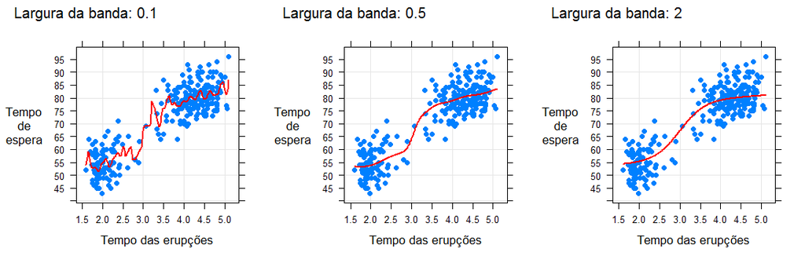

```r
g1 <- xyplot(waiting ~ eruptions,
             type = c("p", "g"),
             pch = 16,
             xlab = "Tempo das erupções",
             ylab = list(label = "Tempo\nde\nespera",
                         rot = 0),
             main = "Largura da banda: 0.1",
             scales = list(x = list(tick.number = 7),
                           y = list(tick.number = 10)),
             par.settings = settings,
             faithful) +
  layer(panel.lines(ksmooth(faithful$eruptions, faithful$waiting,
                            "normal",
                            .1),
                    lwd = 2,
                    col = 2))
g2 <- xyplot(waiting ~ eruptions,
             type = c("p", "g"),
             pch = 16,
             xlab = "Tempo das erupções",
             ylab = list(label = "Tempo\nde\nespera",
                         rot = 0),
             main = "Largura da banda: 0.5",
             scales = list(x = list(tick.number = 7),
                           y = list(tick.number = 10)),
             par.settings = settings,
             faithful) +
  layer(panel.lines(ksmooth(faithful$eruptions, faithful$waiting,
                            "normal",
                            .5),
                    lwd = 2,
                    col = 2))
g3 <- xyplot(waiting ~ eruptions,
             type = c("p", "g"),
             pch = 16,
             xlab = "Tempo das erupções",
             ylab = list(label = "Tempo\nde\nespera",
                         rot = 0),
             main = "Largura da banda: 2",
             scales = list(x = list(tick.number = 7),
                           y = list(tick.number = 10)),
             par.settings = settings,
             faithful) +
  layer(panel.lines(ksmooth(faithful$eruptions, faithful$waiting,
                            "normal",
                            2),
                    lwd = 2,
                    col = 2))
print(g1,
      position = c(0, 0,
                   1/3, 1),
      more = TRUE)
print(g2,
      position = c(1/3, 0,
                   2/3, 1),
      more = TRUE)
print(g3,
      position = c(2/3, 0,
                   1, 1))
```

Validação cruzada (CV: cross-validation) é um popular método de propósito geral. O critério é:

> $CV(\lambda) = \frac{1}{n} \sum_{j = 1}^{n} (y_{j} - \hat{f}_{\lambda (j)} (x_{j}))^{2}$

onde $(j)$ indica que o ponto $j$ é retirado do ajuste. Nós pegamos o $\lambda$ que minimiza este critério.

A verdadeira validação cruzada é cara computacionalmente, por isso uma aproximação para ela, conhecida como validação cruzada generalizada ou GCV (generalized cross-validation), é utilizada em alguns momentos.

# Splines

## Smoothing Splines

Nós escolhemos $\hat{f}$ para minimizar um critério de mínimos quadrados modificado:

> $\frac{1}{n} \sum (y_{i} - f(x_{i}))^{2} + \lambda \int [{f}''(x)]^{2} \text{d}x$

onde $\lambda > 0$ é o parâmetro suavizador e $\int [{f}''(x)]^{2} \text{d}x$ é uma penalidade irregular (rugosa, aspera, grosseira). Quando $f$ é irregular, a penalidade é grande, mas quando $f$ é suave, a penalidade é pequena.

Para esta escolha de penalidade irregular, a solução é de uma particular forma:

$\hat{f}$ é um spline cúbico. Isso significa que $\hat{f}$ é um polinômio cúbico segmentado em cada intervalo ($x_{i}$, $x_{i + 1}$). Isso tem a propriedade que $\hat{f}$, ${\hat{f}}'$ e ${\hat{f}}''$ são contínuas. Dado isso nós sabemos a forma da solução, a estimação é reduzida ao problema paramétrico de estimar os coeficientes de polinômios.

No $\texttt{R}$, validação cruzada é utilizada para selecionar o parâmetro suavizador por padrão.

Nós mostramos a escolha padrão de suavização para três casos teste. Old Faithful, $\texttt{exa}$ e $\texttt{exb}$, sendo os dois últimos do pacote $\texttt{faraway}$:

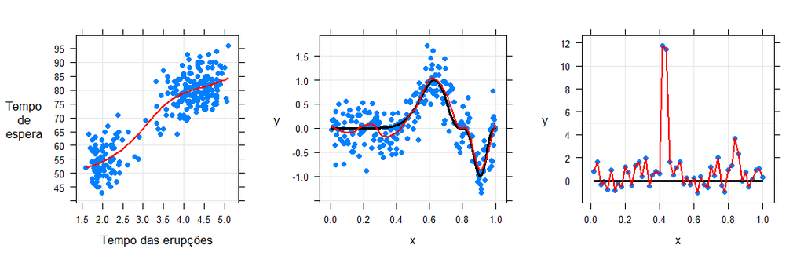

```r
g1 <- xyplot(waiting ~ eruptions,
             type = c("p", "g"),
             pch = 16,
             xlab = "Tempo das erupções",
             ylab = list(label = "Tempo\nde\nespera",
                         rot = 0),
             scales = list(x = list(tick.number = 7),
                           y = list(tick.number = 10)),
             faithful) +
  layer(panel.lines(smooth.spline(faithful$eruptions, faithful$waiting),
                    lwd = 2,
                    col = 2))
g2 <- xyplot(y ~ x,
             type = c("p", "g"),
             pch = 16,
             ylab = list(rot = 0),
             exa) +
  layer(panel.lines(exa$x, exa$m,
                    lwd = 3,
                    col = 1)) +
  layer(panel.lines(smooth.spline(exa$x, exa$y),
                    lwd = 2,
                    col = 2))
g3 <- xyplot(y ~ x,
             type = c("p", "g"),
             pch = 16,
             ylab = list(rot = 0),
             scales = list(y = list(tick.number = 6)),
             exb) +
  layer(panel.lines(exb$x, exb$m,
                    lwd = 3,
                    col = 1)) +
  layer(panel.lines(smooth.spline(exb$x, exb$y),
                    lwd = 2,
                    col = 2))
print(g1,
      position = c(0, 0,
                   1/3, 1),
      more = TRUE)
print(g2,
      position = c(1/3, 0,
                   2/3, 1),
      more = TRUE)
print(g3,
      position = c(2/3, 0,
                   1, 1))
```

## Regression Splines

Os nós (knots) dos B-splines utilizados para as bases são tipicamente muito pequenos em número do que o tamanho da amostra. O número de nós escolhidos controlam a quantidade da suavização. Para suavização splines, os valores únicos observados de $x$ são os nós e $\lambda$ é utilizado para controlar a suavização.

É discutível se o método de regressão spline é paramétrico ou não-paramétrico, porque uma vez que os nós são escolhidos, uma família paramétrica é especificada com um número finito de parâmetros. É a liberdade para escolher o número de nós que faz do método não-paramétrico.

Nós demonstramos algumas regressões por spline aqui. Nós utilizamos splines lineares segmentados nesete exemplo, que é construído e representado graficamente a seguir.

O spline é mostrado no gráfico da esquerda. As funções base são mostradas no gráfico da direita.

```r
rhs <- function(x, c) ifelse(x > c, x - c, 0)
par(mfrow = c(1, 2)) ; curve(rhs(x, .5), 0, 1,
                             lwd = 2,
                             las = 1)
(knots <- 0 : 9/10)
```

```
 [1] 0.0 0.1 0.2 0.3 0.4 0.5 0.6 0.7 0.8 0.9
```

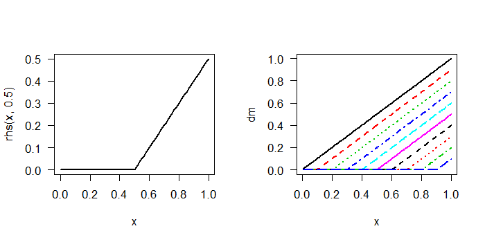

```r
dm <- outer(exa$x, knots, rhs)
matplot(exa$x, dm,
        type = "l",
        xlab = "x",
        lwd = 2,
        las = 1) ; layout(1)
```

Agora nós calculamos e mostramos o ajuste da regressão.

Onde o gráfico é mostrado à esquerda. Por as funções base serem segmentos lineares, o ajuste é também de segmentos lineares.

Um melhor ajuste pode ser obtido ajustando os nós que eles sejam mais densos em regiões de maior curvatura. O gráfico é mostrado à direita.

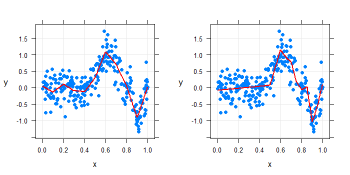

```r
g <- lm(exa$y ~ dm)
g1 <- xyplot(y ~ x,
             type = c("p", "g"),
             pch = 16,
             ylab = list(rot = 0),
             scales = list(y = list(tick.number = 6)),
             exa) +
  layer(panel.lines(exa$x, predict(g),
                    lwd = 2,
                    col = 2))
newknots <- c(0, .5, .6, .65, .7, .75, .8, .85, .9, .95)
dmn <- outer(exa$x, newknots, rhs)
gn <- lm(exa$y ~ dmn)
g2 <- xyplot(y ~ x,
             type = c("p", "g"),
             pch = 16,
             ylab = list(rot = 0),
             scales = list(y = list(tick.number = 6)),
             exa) +
  layer(panel.lines(exa$x, predict(gn),
                    lwd = 2,
                    col = 2))
print(g1,
      position = c(0, 0,
                   .5, 1),
      more = TRUE)
print(g2,
      position = c(.5, 0,
                   1, 1))
```

A função $\texttt{bs()}$ do pacote $\texttt{splines}$ pode ser utilizada para gerar as apropriadas bases dos splines (splines de alta ordem/grau). O padrão é B-splines cúbicos.

Nós mostramos 12 B-splines cúbicos uniformemente espaçados no intervalo $[0, 1]$. Os splines próximos da borda pegam uma diferente forma como visto no gráfico abaixo.

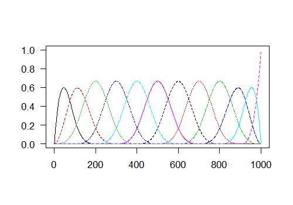

```r
matplot(bs(seq(0, 1, length.out = 1000),
           df = 12),
        type = "l",
        las = 1,
        ylab = "")
```

Nós podemos utilizar mínimos quadrados para determinar os coeficientes. O ajuste é mostrado no gráfico abaixo.

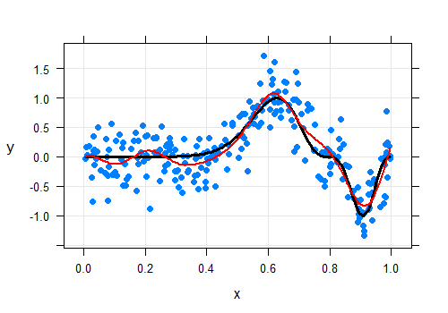

```r
sm1 <- lm(y ~ bs(x, 12), exa)
xyplot(y ~ x,
       type = c("p", "g"),
       pch = 16,
       ylab = list(rot = 0),
       exa) +
  layer(panel.lines(exa$x, exa$m,
                    lwd = 3,
                    col = 1)) +
  layer(panel.lines(exa$x, predict(sm1),
                    lwd = 2,
                    col = 2))
```

# Local Polynomials

Primeiro nós selecionamos uma janela. Nós então ajustamos um polinômio aos dados nessa janela. A resposta predita no meio da janela é o valor ajustado. Nós então simplesmente deslizamos a janela sob o alcance dos dados, repetindo o processo de ajuste nas janelas móveis.

A implementação mais bem conhecida desse tipo de suavização é chamada $lowess$ ou $loess$.

Um termo linear é a escolha padrão na função $loess$.

É importante selecionar bem a largura da janela. A escolha padrão pega três quartos dos dados.

Para o dado Old Faithful a escolha padrão é satisfatória, como visto no gráfico da esquerda.

Para o dado $\texttt{exa}$, a escolha padrão é muito larga. A escolha que minimiza o erro quadrático integrado entre a estimativa e a verdadeira função necessita de um alcance ( proporção da extensão dos dados) de 0.22. Ambos os ajustes são mostrados na gráfico do meio.

Para o dado $\texttt{exb}$, a escolha ótima de alcance é um (isso é todos os dados). Isso não é uma surpresa já que a verdadeira função é uma constante e então uma suavização máxima é desejada. Nós podemos ver que as qualidades robustas do loess previnem o ajuste de se tornar muito distorcido pelos dois outliers mesmo com a escolha padrão de alcance da suavização.

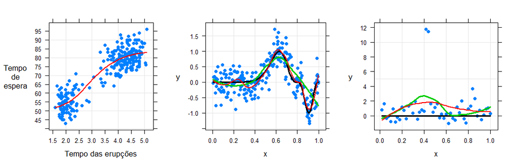

```r
g1 <- xyplot(waiting ~ eruptions,
             type = c("p", "g"),
             pch = 16,
             xlab = "Tempo das erupções",
             ylab = list(label = "Tempo\nde\nespera",
                         rot = 0),
             scales = list(x = list(tick.number = 7),
                           y = list(tick.number = 10)),
             faithful) +
  layer(panel.lines(loess(waiting ~ eruptions, faithful)$x[order(faithful$eruptions)],
                    loess(waiting ~ eruptions, faithful)$fitted[order(faithful$eruptions)],
                    lwd = 2,
                    col = 2))
g2 <- xyplot(y ~ x,
             type = c("p", "g"),
             pch = 16,
             ylab = list(rot = 0),
             exa) +
  layer(panel.lines(exa$x, exa$m,
                    lwd = 3,
                    col = 1)) +
  layer(panel.lines(loess(y ~ x, exa)$x, loess(y ~ x, exa)$fitted,
                    lwd = 3,
                    col = 3)) +
  layer(panel.lines(loess(y ~ x, exa,
                          span = .22)$x,
                    loess(y ~ x, exa,
                          span = .22)$fitted,
                    lwd = 2,
                    col = 2))
g3 <- xyplot(y ~ x,
             type = c("p", "g"),
             pch = 16,
             ylab = list(rot = 0),
             scales = list(y = list(tick.number = 6)),
             exb) +
  layer(panel.lines(exb$x, exb$m,
                    lwd = 3,
                    col = 1)) +
  layer(panel.lines(loess(y ~ x, exb)$x, loess(y ~ x, exb)$fitted,
                    lwd = 3,
                    col = 3)) +
  layer(panel.lines(loess(y ~ x, exb,
                          span = 1)$x,
                    loess(y ~ x, exb,
                          span = 1)$fitted,
                    lwd = 2,
                    col = 2))
print(g1,
      position = c(0, 0,
                   1/3, 1),
      more = TRUE)
print(g2,
      position = c(1/3, 0,
                   2/3, 1),
      more = TRUE)
print(g3,
      position = c(2/3, 0,
                   1, 1))
```

# Nearest Neighbor

Nós definimos $\hat{f}_{\lambda} (x) =$ média dos $\lambda$ vizinhos mais próximos de $x$. Nós deixamos a largura da janela variar para acomodar o mesmo número de pontos. Nós precisamos selecionar o número de vizinhos a serem utilizados, validação cruzada pode ser utilizada para este propósito.

# Running Medians

Regressão não-paramétrica é mais robusta que regressão paramétrica no sentido de modelos, mas isso não significa que ela é robosta para outliers.

Métodos baseados em médias locais são sensíveis para outliers, então a mediana pode ser útil. Nós deixamos $N(x, \lambda) = \{i: x_{i}$ é um dos $\lambda$ vizinhos mais próximos de $x\}$ então:

> $\hat{f}_{\lambda} (x) = \text{mediana}\{Y_{i} \text{ tal que } i \in N(x, \lambda)$

Este método é robusto para outliers, mas produz a ajuste com aparência irregular/rugosa. Pode-se querer suavizar novamente utilizando outro método. Isso é chamada=o de twicing.

Nós achamos que o suavizador loess faz uma boa suavização em todos os propósitos. Ele é robusto para outliers e ainda pode produzir ajustes suaves.

Quando você está confiante que outliers não estão presentes, suavização por splines é mais eficiente que polinômios locais.

> Maldição da dimensionalidade:  
> Você precisa de um número extremamente grande de pontos para cobrir um espaço de alta dimensão para alta densidade.